# Gemma Bex meta-analysis Gene Comparisons

Emma Walker

Note: This is an edited version of the GeneListComparisons2.rmd script (now in ‘scratch’). Changes have been made to the following:

1. only using chipseeker annotations for RRBS data (reannotated to 1500bp window)
2. array data has been re-annotated using the Array_reannotateResultsFilesTSS1500bp.r script so cpgs are only annotated to a gene if they are genic or +/-1500bp from TSS. This aligns with the RRBS chipseeker annotations (scripts 05bx.r) which also use a 1500bp window.
3. Venn diagrams for all pathology models

# Overlap with Gemma/Bex meta-analysis results

There are 184 unique genes which were annotated to significant DMPs in the 2021 meta-analysis results file. However 29 of these do not have a mouse analogue, leaving 155 for comparison.

The tables below shows how many of these genes are also annotated to a significant site in the RRBS and array data results files

### RRBS rTg4510

RRBS rTg4510

| Model.Term | N.Results | N.Genes | N.Overlaps |
| --- | --- | --- | --- |
| Age | 5799 | 1457 | 26 |
| Genotype | 1977 | 530 | 10 |
| Interaction | 2203 | 543 | 11 |
| Pathology | 8184 | 1970 | 34 |

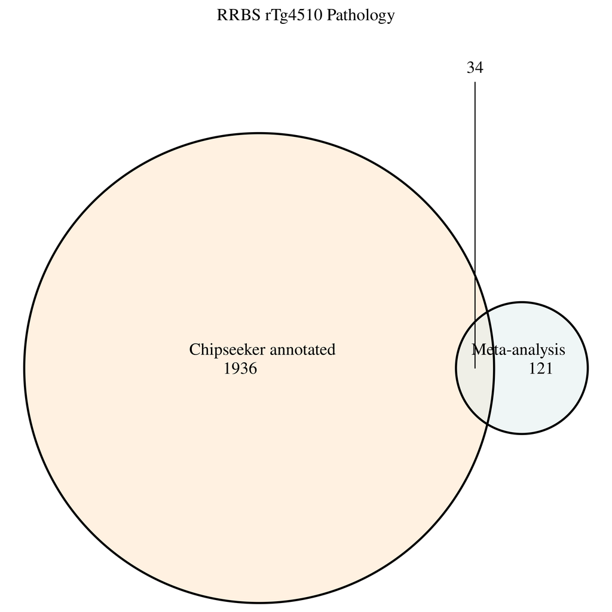

rTg4510 Pathology

List of RRBS rTg4510 genes (annotated with chipseeker) which overlap with the meta-analysis gene list:

| Age | Genotype | Interaction | Pathology |
| --- | --- | --- | --- |
| Abr | Ank1 | Ank1 | 0610040J01Rik |
| Ank1 | Gng7 | Camta1 | Ablim1 |
| Arhgef10 | Map7 | Edaradd | Abr |
| Camta1 | Nrxn2 | Erg | Adam10 |
| Cdh23 | Prdm16 | Gng7 | Adk |
| Cux2 | Rasgef1c | Map7 | Agap2 |
| Ddr1 | Runx3 | Nrxn2 | Ank1 |
| Dlgap2 | Sorbs2 | Prdm16 | Arfgef1 |
| Edaradd | Synj2 | Sorbs2 | Arhgef10 |
| Erg | Tmem150b | Synj2 | Arid3a |
| Fbxl14 |  | Tmem150b | Camta1 |
| Hoxb3 |  |  | Col25a1 |
| Kdm2b |  |  | Cux2 |
| Myo1c |  |  | Dlgap2 |
| Nav2 |  |  | Gcnt2 |
| Plat |  |  | Gng7 |
| Plch1 |  |  | Hoxa4 |
| Prdm16 |  |  | Hoxb3 |
| Rasgef1c |  |  | Kdm2b |
| Runx3 |  |  | Lhpp |
| Skap1 |  |  | Map3k14 |
| Synj2 |  |  | Mbp |
| Tns3 |  |  | Mta3 |
| Ube2o |  |  | Nav2 |
| Xirp1 |  |  | Nrxn2 |
| Zfpm1 |  |  | Phactr1 |
|  |  |  | Plch1 |
|  |  |  | Prdm16 |
|  |  |  | Runx3 |
|  |  |  | Slco2b1 |
|  |  |  | St7 |
|  |  |  | Tbc1d2b |
|  |  |  | Thra |
|  |  |  | Tnrc6c |

### RRBS J20

RRBS J20

| Model.Term | N.Results | N.Genes | N.Overlaps | N.COverlaps |
| --- | --- | --- | --- | --- |
| Age | 6248 | 1369 | NA | 20 |
| Genotype | 4265 | 1027 | NA | 16 |
| Interaction | 4037 | 911 | NA | 12 |
| Pathology | 3489 | 806 | NA | 16 |

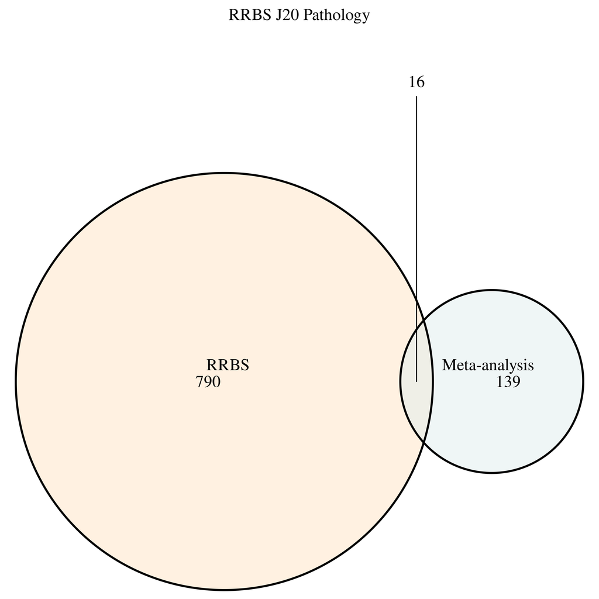

J20 Pathology

List of RRBS J20 genes (annotated with chipseeker) which overlap with the meta-analysis gene list:

| Age | Genotype | Interaction | Pathology |
| --- | --- | --- | --- |
| Agap2 | Agap2 | 0610040J01Rik | Arhgef10 |
| Arhgef10 | Arfgef1 | Arfgef1 | Arhgef17 |
| Arid3a | Arid3a | Arid3a | Cdh23 |
| Cdh23 | Atg16l2 | Camta1 | Creb5 |
| Erg | Camta1 | Cdh23 | Hoxa5 |
| Kdm2b | Cdh23 | Erg | Map3k14 |
| Map3k14 | Dlgap2 | Nav2 | Map7 |
| Mbp | Edaradd | Nrxn2 | Mbp |
| Nav2 | Erg | Prdm16 | Mcf2l |
| Osbpl5 | Map4k1 | Rac1 | Nrxn2 |
| Prdm16 | Nav2 | Rnf112 | Plch1 |
| Rgma | Nrxn2 | Tspan14 | Prdm16 |
| Rin3 | Prdm16 |  | Runx2 |
| Sec14l1 | Rnf112 |  | Runx3 |
| Smurf1 | Thbs1 |  | Serp2 |
| Sorbs2 | Tspan14 |  | Tbc1d1 |
| St7 |  |  |  |
| Tpst1 |  |  |  |
| Trappc9 |  |  |  |
| Zfpm1 |  |  |  |

### Array rTg4510

Array rTg4510

| Model.Term | N.ECX.Results | N.ECX.Genes | N.ECX.Overlaps | N.HIP.Results | N.HIP.Genes | N.HIP.Overlaps |
| --- | --- | --- | --- | --- | --- | --- |
| Age | 276 | 193 | 1 | 809 | 498 | 11 |
| Genotype | 46 | 39 | 1 | 374 | 238 | 4 |
| Interaction | 928 | 485 | 6 | 1649 | 746 | 18 |
| Pathology | 2260 | 959 | 18 | 8876 | 2324 | 43 |
| Genotype.Only | 1804 | 833 | 16 | 9240 | 2385 | 44 |

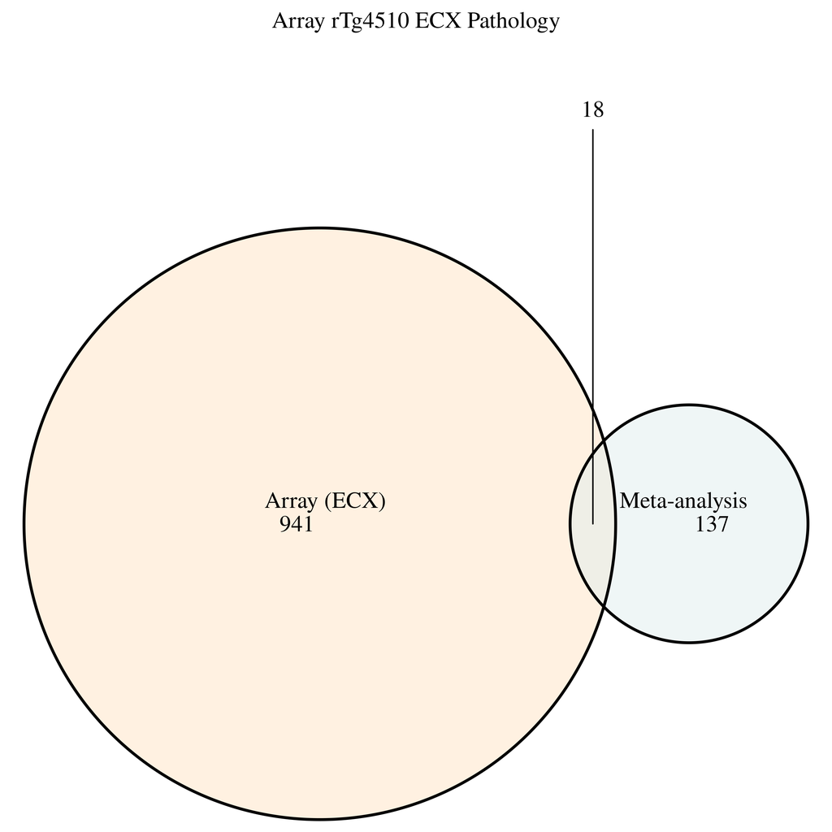

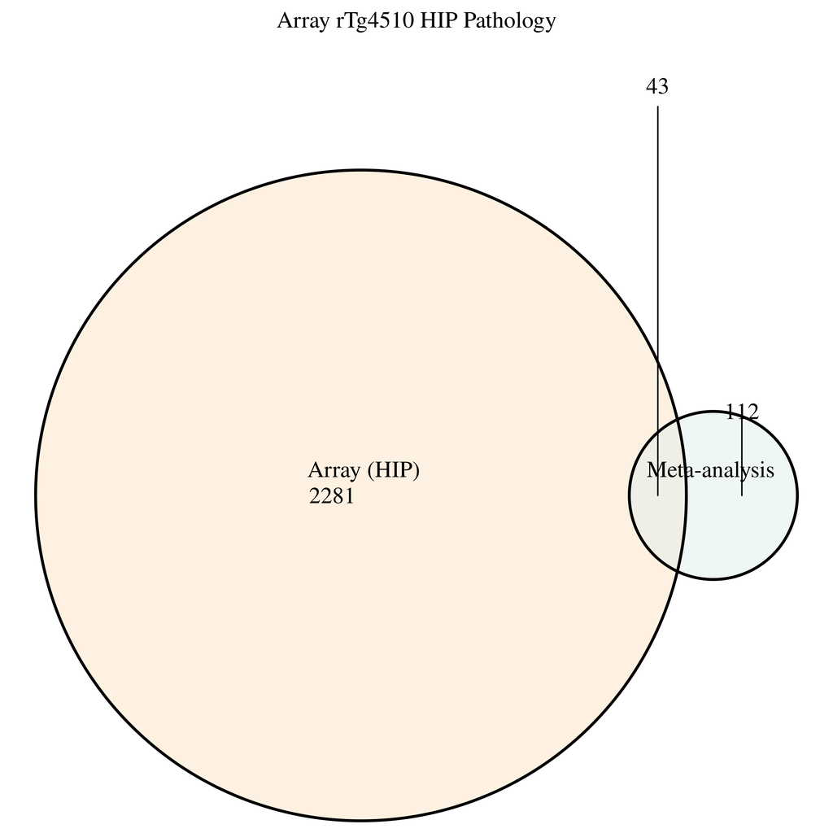

rTg4510

List of array rTg4510 genes which overlap with the meta-analysis gene list:

| ECX.Age | ECX.Genotype | ECX.Interaction | ECX.Pathology | ECX.Genotype.Only | HIP.Age | HIP.Genotype | HIP.Interaction | HIP.Pathology | HIP.Genotype.Only |
| --- | --- | --- | --- | --- | --- | --- | --- | --- | --- |
| Tnrc6c | Tnrc6c | Adk | Adk | Adk | Cdh23 | Cpeb4 | Adk | Adam10 | Ablim1 |
|  |  | Pik3r5 | Agap2 | Btbd11 | Fbxl14 | Cxxc5 | Agap2 | Adk | Adk |
|  |  | Prdm16 | Camta1 | Cpeb4 | Hoxa2 | Hoxa2 | Btbd11 | Agap2 | Agap2 |
|  |  | Runx2 | Cpeb1 | Cux2 | Hoxa4 | Runx2 | Camta1 | Ankrd11 | Arhgap23 |
|  |  | Runx3 | Cpeb4 | Cxxc5 | Hoxa5 |  | Cdh23 | Arhgap23 | Btbd11 |
|  |  | Tnrc6c | Cux2 | Erg | Hoxb3 |  | Cux2 | Btbd11 | Camta1 |
|  |  |  | Cxxc5 | Hoxa4 | Lhpp |  | Cxxc5 | Camta1 | Cdh23 |
|  |  |  | Erg | Hoxb3 | Prdm16 |  | Hoxa2 | Cdh23 | Cpeb1 |
|  |  |  | Hoxa2 | Hoxb9 | Smurf1 |  | Hsf4 | Cpeb1 | Cpeb4 |
|  |  |  | Hoxa4 | Kdm2b | Synj2 |  | Mbp | Cpeb4 | Cux2 |
|  |  |  | Hoxb3 | Pik3r5 | Tnrc6c |  | Phactr1 | Creb5 | Cxxc5 |
|  |  |  | Pik3r5 | Prdm16 |  |  | Pik3r5 | Cux2 | Dnaic1 |
|  |  |  | Prdm16 | Runx2 |  |  | Runx2 | Cxxc5 | Erg |
|  |  |  | Runx2 | Synj2 |  |  | Runx3 | Fbxl14 | Fbxl14 |
|  |  |  | Runx3 | Taf4 |  |  | Skap1 | Gucy2e | Gucy2e |
|  |  |  | Skap1 | Tnrc6c |  |  | Synj2 | Hoxa2 | Hoxa2 |
|  |  |  | Synj2 |  |  |  | Thra | Hoxa4 | Hoxa4 |
|  |  |  | Tnrc6c |  |  |  | Tnrc6c | Hoxa5 | Hoxb3 |
|  |  |  |  |  |  |  |  | Hoxb3 | Hoxb9 |
|  |  |  |  |  |  |  |  | Hoxb9 | Hsf4 |
|  |  |  |  |  |  |  |  | Hsf4 | Kdm2b |
|  |  |  |  |  |  |  |  | Kdm2b | Kif21b |
|  |  |  |  |  |  |  |  | Kif21b | Loxl1 |
|  |  |  |  |  |  |  |  | Mad1l1 | Mad1l1 |
|  |  |  |  |  |  |  |  | Mbp | Mbp |
|  |  |  |  |  |  |  |  | Mta3 | Mta3 |
|  |  |  |  |  |  |  |  | Nav2 | Nav2 |
|  |  |  |  |  |  |  |  | Phactr1 | Phactr1 |
|  |  |  |  |  |  |  |  | Pik3r5 | Pik3r5 |
|  |  |  |  |  |  |  |  | Prdm16 | Prdm16 |
|  |  |  |  |  |  |  |  | Prkcz | Prkcz |
|  |  |  |  |  |  |  |  | Runx2 | Rgma |
|  |  |  |  |  |  |  |  | Runx3 | Runx2 |
|  |  |  |  |  |  |  |  | Skap1 | Runx3 |
|  |  |  |  |  |  |  |  | Sorbs2 | Skap1 |
|  |  |  |  |  |  |  |  | Spi1 | Sorbs2 |
|  |  |  |  |  |  |  |  | St7 | Spi1 |
|  |  |  |  |  |  |  |  | Synj2 | St7 |
|  |  |  |  |  |  |  |  | Taf4 | Synj2 |
|  |  |  |  |  |  |  |  | Tbc1d1 | Taf4 |
|  |  |  |  |  |  |  |  | Thra | Tbc1d1 |
|  |  |  |  |  |  |  |  | Tnrc6c | Thra |
|  |  |  |  |  |  |  |  | Ube2o | Tnrc6c |
|  |  |  |  |  |  |  |  |  | Ube2o |

### Array J20

Array J20

| Model.Term | N.ECX.Results | N.ECX.Genes | N.ECX.Overlaps | N.HIP.Results | N.HIP.Genes | N.HIP.Overlaps |
| --- | --- | --- | --- | --- | --- | --- |
| Age | 60 | 44 | 0 | 346 | 243 | 4 |
| Genotype | 12 | 10 | 0 | 71 | 52 | 1 |
| Interaction | 0 | NA | NA | 37 | 30 | 0 |
| Pathology | 24 | 22 | 0 | 2077 | 823 | 16 |
| Genotype.Only | 909 | 536 | 6 | 3761 | 1249 | 19 |

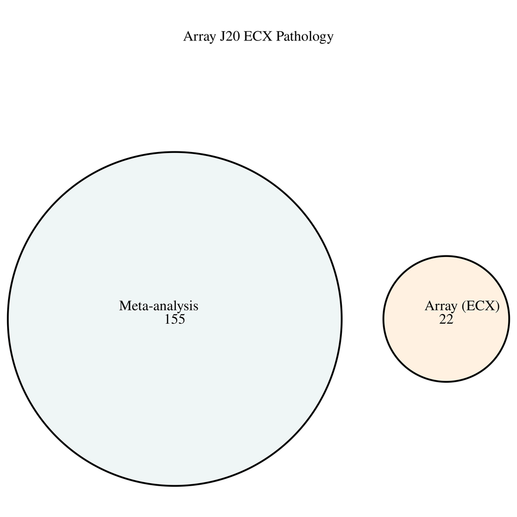

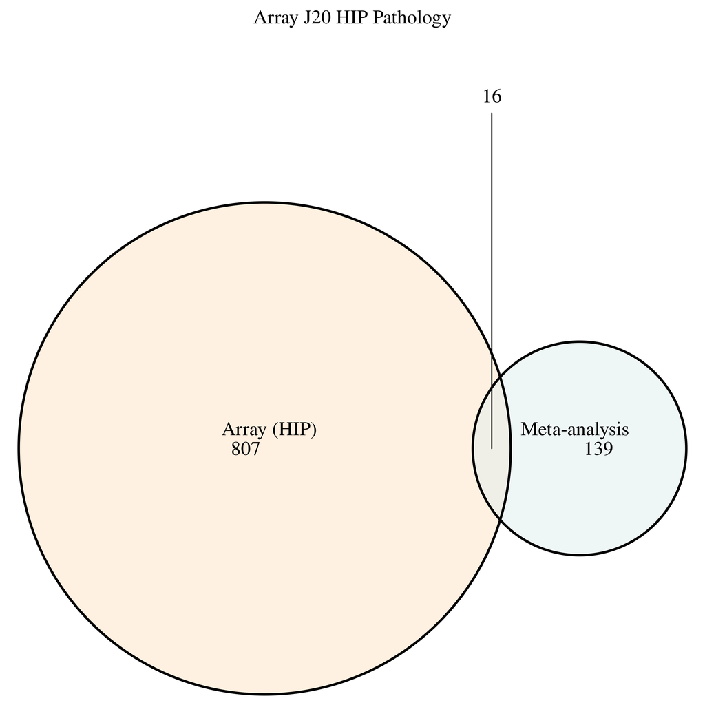

J20

List of array J20 genes which overlap with the meta-analysis gene list:

| ECX.Age | ECX.Genotype | ECX.Interaction | ECX.Pathology | ECX.Genotype.Only | HIP.Age | HIP.Genotype | HIP.Interaction | HIP.Pathology | HIP.Genotype.Only |
| --- | --- | --- | --- | --- | --- | --- | --- | --- | --- |
|  |  |  |  | Adam10 | Cpeb4 | Ube2o |  | Adk | Adk |
|  |  |  |  | Ankrd11 | Cxxc5 |  |  | Cpeb4 | Cdh23 |
|  |  |  |  | Cxxc5 | Taf4 |  |  | Cxxc5 | Cpeb4 |
|  |  |  |  | Hoxa4 | Ube2o |  |  | Hoxa2 | Cux2 |
|  |  |  |  | Skap1 |  |  |  | Hoxa4 | Cxxc5 |
|  |  |  |  | Tbc1d2b |  |  |  | Hoxb3 | Hoxb3 |
|  |  |  |  |  |  |  |  | Map7 | Hoxb9 |
|  |  |  |  |  |  |  |  | Mbp | Map7 |
|  |  |  |  |  |  |  |  | Mta3 | Mbp |
|  |  |  |  |  |  |  |  | Nav2 | Mta3 |
|  |  |  |  |  |  |  |  | Pik3r5 | Nav2 |
|  |  |  |  |  |  |  |  | Prdm16 | Phactr1 |
|  |  |  |  |  |  |  |  | Runx2 | Pik3r5 |
|  |  |  |  |  |  |  |  | Skap1 | Prdm16 |
|  |  |  |  |  |  |  |  | Synj2 | Runx2 |
|  |  |  |  |  |  |  |  | Ube2o | Skap1 |
|  |  |  |  |  |  |  |  |  | Synj2 |
|  |  |  |  |  |  |  |  |  | Tnrc6c |
|  |  |  |  |  |  |  |  |  | Ube2o |

### Union of RRBS and Array rTg4510 genes

| Model.Term | N.RRBS.Genes | N.Array.Genes | N.Total.Genes | N.Overlaps |
| --- | --- | --- | --- | --- |
| Age | 1457 | 193 | 1615 | 27 |
| Genotype | 530 | 39 | 566 | 11 |
| Interaction | 543 | 485 | 998 | 16 |
| Pathology | 1970 | 959 | 2689 | 43 |

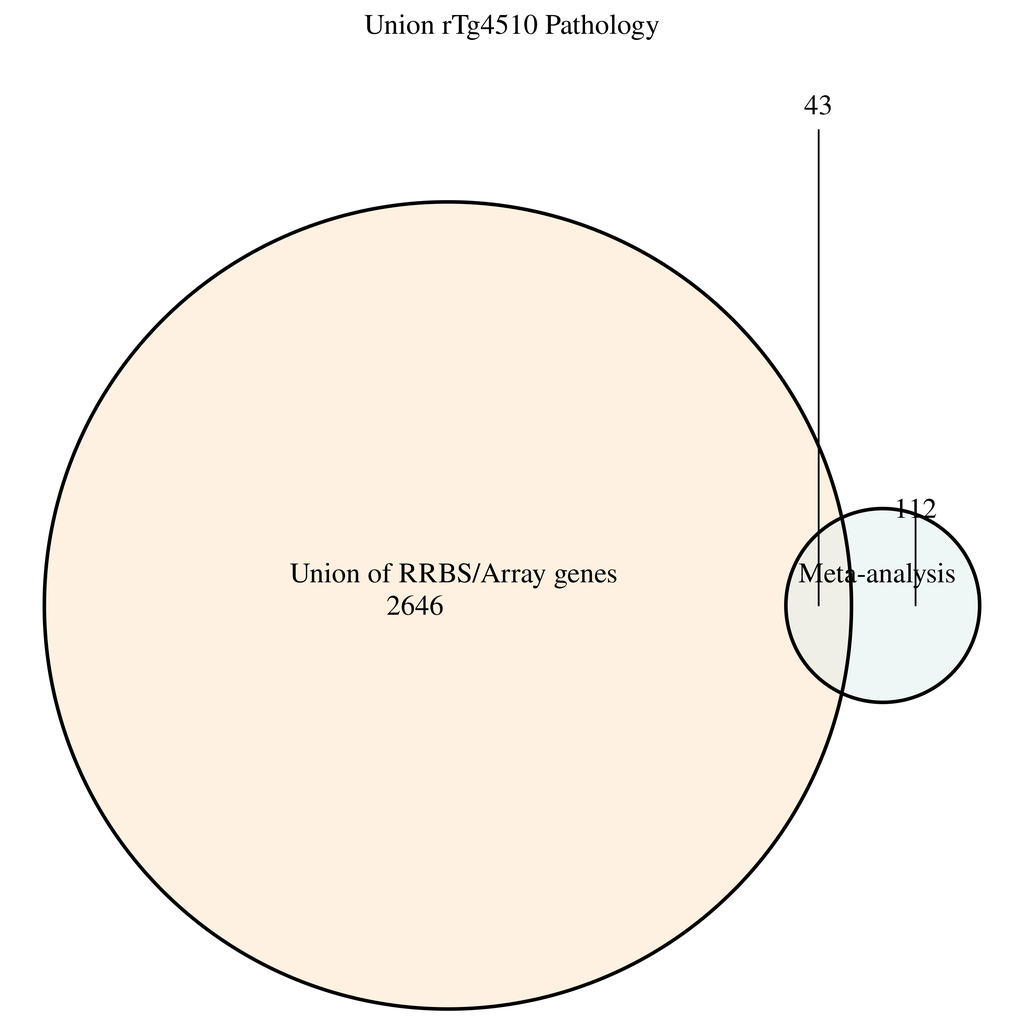

Union Pathology

| Age | Genotype | Interaction | Pathology |
| --- | --- | --- | --- |
| Abr | Ank1 | Adk | 0610040J01Rik |
| Ank1 | Gng7 | Ank1 | Ablim1 |
| Arhgef10 | Map7 | Camta1 | Abr |
| Camta1 | Nrxn2 | Edaradd | Adam10 |
| Cdh23 | Prdm16 | Erg | Adk |
| Cux2 | Rasgef1c | Gng7 | Agap2 |
| Ddr1 | Runx3 | Map7 | Ank1 |
| Dlgap2 | Sorbs2 | Nrxn2 | Arfgef1 |
| Edaradd | Synj2 | Pik3r5 | Arhgef10 |
| Erg | Tmem150b | Prdm16 | Arid3a |
| Fbxl14 | Tnrc6c | Runx2 | Camta1 |
| Hoxb3 |  | Runx3 | Col25a1 |
| Kdm2b |  | Sorbs2 | Cpeb1 |
| Myo1c |  | Synj2 | Cpeb4 |
| Nav2 |  | Tmem150b | Cux2 |
| Plat |  | Tnrc6c | Cxxc5 |
| Plch1 |  |  | Dlgap2 |
| Prdm16 |  |  | Erg |
| Rasgef1c |  |  | Gcnt2 |
| Runx3 |  |  | Gng7 |
| Skap1 |  |  | Hoxa2 |
| Synj2 |  |  | Hoxa4 |
| Tnrc6c |  |  | Hoxb3 |
| Tns3 |  |  | Kdm2b |
| Ube2o |  |  | Lhpp |
| Xirp1 |  |  | Map3k14 |
| Zfpm1 |  |  | Mbp |
|  |  |  | Mta3 |
|  |  |  | Nav2 |
|  |  |  | Nrxn2 |
|  |  |  | Phactr1 |
|  |  |  | Pik3r5 |
|  |  |  | Plch1 |
|  |  |  | Prdm16 |
|  |  |  | Runx2 |
|  |  |  | Runx3 |
|  |  |  | Skap1 |
|  |  |  | Slco2b1 |
|  |  |  | St7 |
|  |  |  | Synj2 |
|  |  |  | Tbc1d2b |
|  |  |  | Thra |
|  |  |  | Tnrc6c |

### Union of RRBS and Array J20 genes

| Model.Term | N.RRBS.Genes | N.Array.Genes | N.Total.Genes | N.Overlaps |
| --- | --- | --- | --- | --- |
| Age | 1369 | 44 | 1407 | 20 |
| Genotype | 1027 | 10 | 1036 | 16 |
| Pathology | 806 | 22 | 827 | 16 |

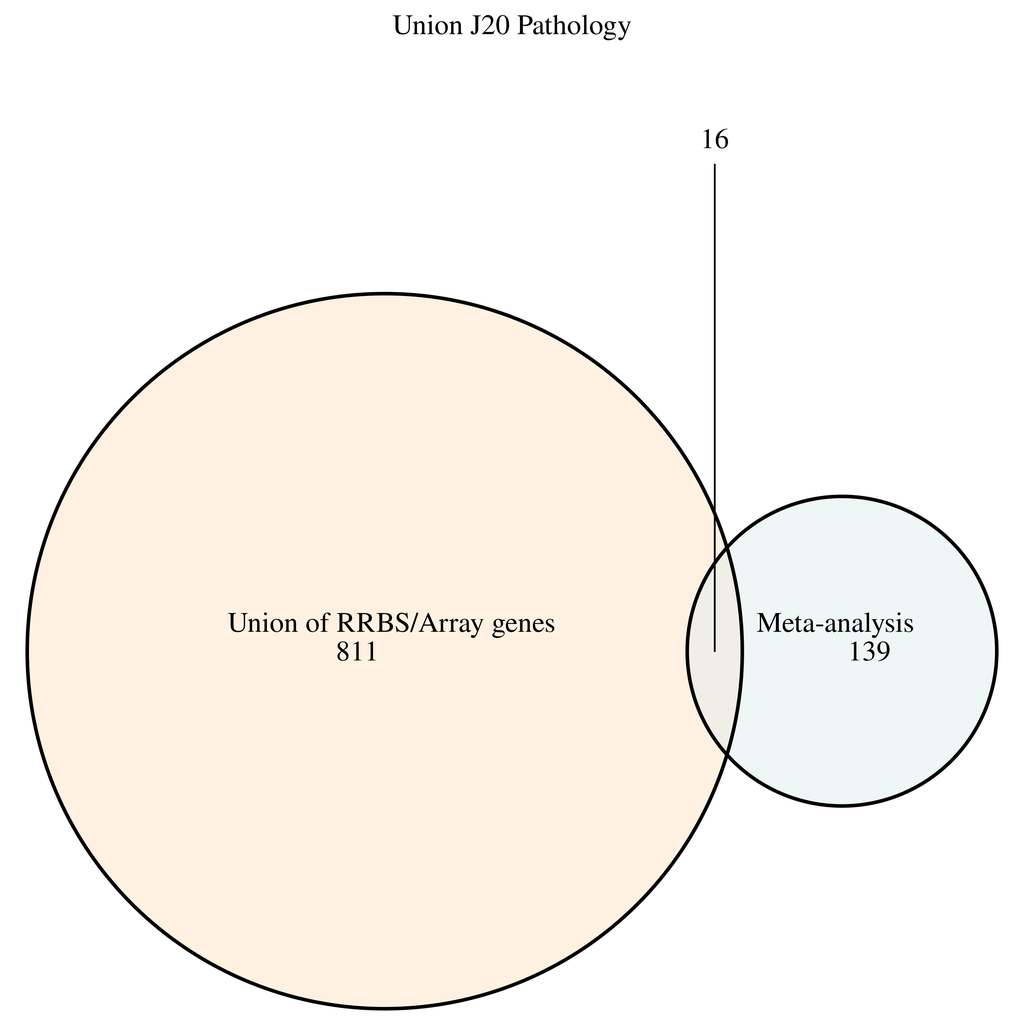

J20 Union Pathology

| Age | Genotype | Pathology |
| --- | --- | --- |
| Agap2 | Agap2 | Arhgef10 |
| Arhgef10 | Arfgef1 | Arhgef17 |
| Arid3a | Arid3a | Cdh23 |
| Cdh23 | Atg16l2 | Creb5 |
| Erg | Camta1 | Hoxa5 |
| Kdm2b | Cdh23 | Map3k14 |
| Map3k14 | Dlgap2 | Map7 |
| Mbp | Edaradd | Mbp |
| Nav2 | Erg | Mcf2l |
| Osbpl5 | Map4k1 | Nrxn2 |
| Prdm16 | Nav2 | Plch1 |
| Rgma | Nrxn2 | Prdm16 |
| Rin3 | Prdm16 | Runx2 |
| Sec14l1 | Rnf112 | Runx3 |
| Smurf1 | Thbs1 | Serp2 |
| Sorbs2 | Tspan14 | Tbc1d1 |
| St7 |  |  |
| Tpst1 |  |  |
| Trappc9 |  |  |
| Zfpm1 |  |  |